# Experimental treatment with edaravone in a mouse model of spinocerebellar ataxia 1

Analysis of ELISA (brain IL6 and BDNF levels)

Author

Martina Sucha, Simona Benediktova, Filip Tichanek, Jan Jedlicka, Stepan Kapl, Dana Jelinkova, Zdenka Purkartova, Jan Tuma, Jitka Kuncova, Jan Cendelin

This page shows R code for the study [Sucha et al.](https://www.mdpi.com/1422-0067/24/13/10689) (2023, *International Journal of Molecular Science*).

**Citation**:

> Sucha M, Benediktova S, Tichanek F, Jedlicka J, Kapl S, Jelinkova D, Purkartova Z, Tuma J, Kuncova J, Cendelin J. Experimental Treatment with Edaravone in a Mouse Model of Spinocerebellar Ataxia 1. International Journal of Molecular Sciences. 2023; 24(13):10689. https://doi.org/10.3390/ijms241310689

[GitHub page](https://github.com/filip-tichanek/edaravonSCA1): https://github.com/filip-tichanek/edaravonSCA1

ELISA was used to measure:

- 1. hippocampal levels of interleukin 6 (*IL6*, marker of inflammation)
- 2. cerebellar level of *IL6*
- 3. cerebellar level of *Brain-derived neurotrophic factor* (*BDNF*, neuroplasticity-related protein)

# 1 Upload of packages

```r
rm(list = ls())

suppressWarnings(suppressMessages( {
library(brms)
library(beeswarm)
library(vioplot)
library(glmmTMB)
library(car)
library(cowplot)
library(ggplot2)
library(tidyverse)
library(bayesplot)
library(gtsummary)
library(vegan)
library(knitr)
library(ggplot2)
  } ) )
```

# 2 Data upload and wrangling

```r
## Data upload
load("source_data/myEnvironment.RData")
elisa<-read.csv("source_data/elisa_data.csv",stringsAsFactors = T)
summary(elisa)
```

```
       id         treatment genotype sex     tissue        il6
 Min.   :  1.00   ctrl:32   sca:32   f:32   crbl:32   Min.   :24.09
 1st Qu.: 42.75   eda :32   wt :32   m:32   hip :32   1st Qu.:34.57
 Median : 62.50                                       Median :47.29
 Mean   : 58.34                                       Mean   :43.97
 3rd Qu.: 76.25                                       3rd Qu.:51.47
 Max.   :121.00                                       Max.   :58.45

      bdnf           X
 Min.   : 9.907   Mode:logical
 1st Qu.:13.477   NA's:64
 Median :15.211
 Mean   :15.702
 3rd Qu.:17.591
 Max.   :25.690
 NA's   :32
```

```r
## Defining new variables
elisa$group<-interaction(elisa$treatment,elisa$genotype)
elisa$group<-factor(elisa$group,levels=c('ctrl.wt','eda.wt','ctrl.sca','eda.sca'))
elisa$sex_num<-ifelse(elisa$sex=="f",-0.5,0.5)

elisa$group_sex<-interaction(elisa$treatment,elisa$genotype,elisa$sex)
elisa$group_sex<-factor(elisa$group_sex, levels=c('ctrl.wt.f','ctrl.wt.m',
                                                 'eda.wt.f','eda.wt.m',
                                                 'ctrl.sca.f','ctrl.sca.m',
                                                 'eda.sca.f','eda.sca.m'))

## subseting datasets
elisa_hp<-subset(elisa,elisa$tissue=='hip')
elisa_cb<-subset(elisa,elisa$tissue=='crbl')
elisa_bdnf <- subset(elisa,elisa$bdnf != 'NA')
```

# 3 Hippocampal IL6

## 3.1 Data exploration

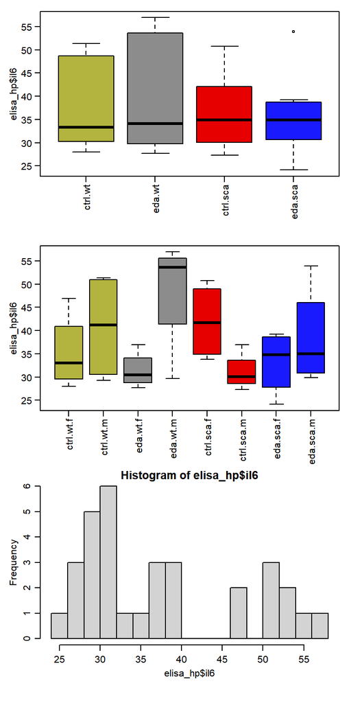

```r
par(mar=c(5,3.5,1,1))
par(mgp=c(1.9,0.7,0))
par(mfrow=c(3,1))


plot(elisa_hp$il6~elisa_hp$group,las=2,xlab="",
     col=cola)

plot(elisa_hp$il6~elisa_hp$group_sex,las=2,xlab="",
     col=cola[c(1,1,2,2,3,3,4,4)])

hist(elisa_hp$il6, 12)
```

There is no consistent sex-related difference. Groups with larger value show larger spread and the distribution seems right-tailed. Thus gamma model seems as natural choice. It will be used along Gaussian models and they will be compared with *posterior predictive check* (PPC)

## 3.2 Modelling

### 3.2.1 Setting priors

Summary statistics and other information used for prior specification

```r
elisa_hp$group<-relevel(elisa_hp$group,ref='ctrl.sca')

## prior for gamma models
log(mean(elisa_hp$il6))
```

```
[1] 3.626034
```

```r
sd(log(elisa_hp$il6))*5
```

```
[1] 1.233038
```

```r
## prior for Gaussian model
mean(elisa_hp$il6)
```

```
[1] 37.56354
```

```r
sd(elisa_hp[elisa_hp$genotype=="sca",]$il6) * c(5, 2, 1.2)
```

```
[1] 41.88630 16.75452 10.05271
```

```r
sd(elisa_hp[elisa_hp$genotype=="wt",]$il6) * c(5, 2, 1.2)
```

```
[1] 54.89251 21.95700 13.17420
```

```r
sd(elisa_hp$il6)* c(5, 2, 1.2)
```

```
[1] 48.54912 19.41965 11.65179
```

Defining priors

```r
## Priors for gamma model
prior01 <- c(set_prior("student_t(3, 3.62, 1.23)", class = "b", coef = "Intercept"),
             set_prior("normal(0,2)", class = "b", coef = "groupctrl.wt"),
             set_prior("normal(0,2)", class = "b", coef = "groupeda.wt"),
             set_prior("normal(0,1.2)"  , class = "b", coef = "groupeda.sca"))

## Priors for Gaussian model
prior02 <- c(set_prior("student_t(3, 37, 45)", class = "b", coef = "Intercept"),
             set_prior("normal(0,22)", class = "b", coef = "groupctrl.wt"),
             set_prior("normal(0,22)", class = "b", coef = "groupeda.wt"),
             set_prior("normal(0,11)"  , class = "b", coef = "groupeda.sca"))
```

### 3.2.2 Fitting models and convergence check

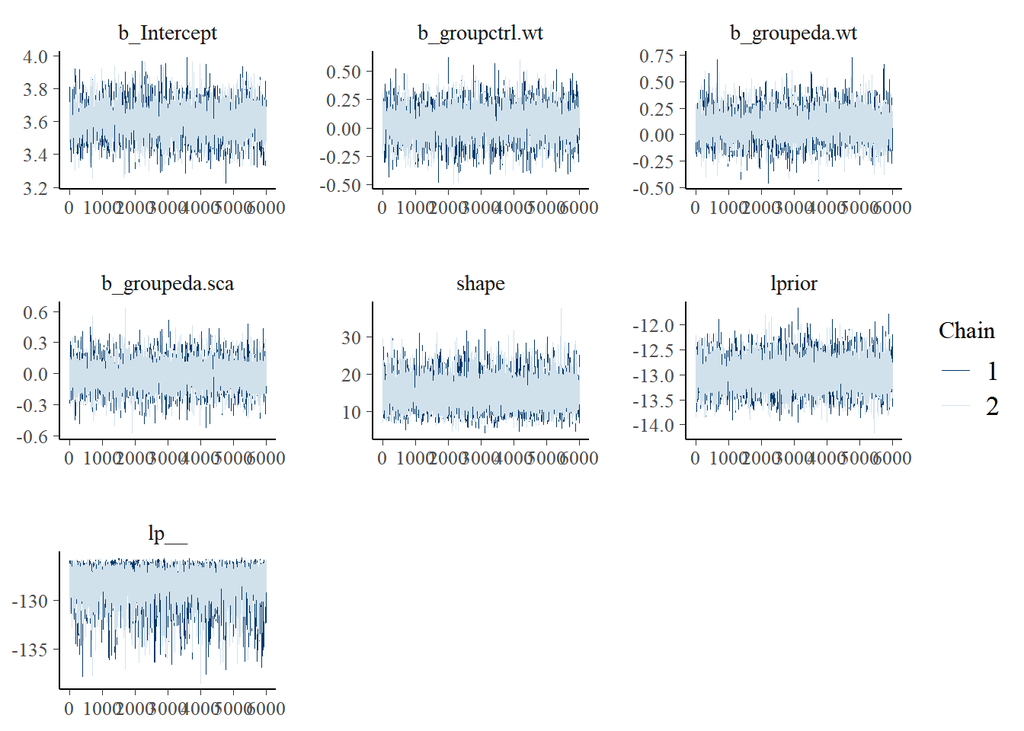

```r
## gamma model
elisa_hp_model_01 <- run_model(
                brm(il6 ~0+Intercept+group,
                      data=elisa_hp, prior = prior01,
                      family=Gamma(link="log"),
                      save_pars = save_pars(all = TRUE),
                      iter=8000, warmup=2000,chains=2,cores=1,seed=17,
                      control = list(adapt_delta = 0.99)),
                 'output/brm/elisa_hp_model_01', reuse = TRUE)

## Gaussian model
elisa_hp_model_02 <- run_model(
              brm(il6~0+Intercept+group,
                      data=elisa_hp, prior = prior02,
                      family=gaussian(),
                      save_pars = save_pars(all = TRUE),
                      iter=8000, warmup=2000,chains=2,cores=1,seed=17,
                      control = list(adapt_delta = 0.99)),
                 'output/brm/elisa_hp_model_02', reuse = TRUE)

mcmc_trace(elisa_hp_model_01)
```

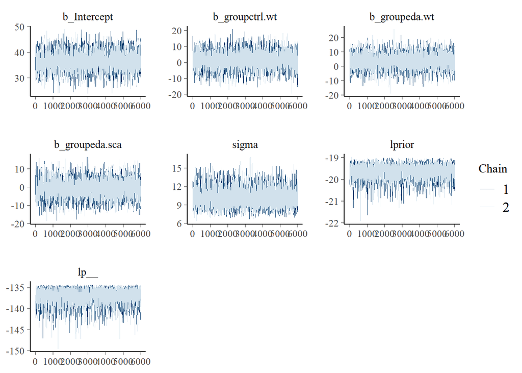

```r
mcmc_trace(elisa_hp_model_02)
```

```r
summary(elisa_hp_model_01)
```

```
 Family: gamma
  Links: mu = log; shape = identity
Formula: il6 ~ 0 + Intercept + group
   Data: elisa_hp (Number of observations: 32)
  Draws: 2 chains, each with iter = 8000; warmup = 2000; thin = 1;
         total post-warmup draws = 12000

Population-Level Effects:
             Estimate Est.Error l-95% CI u-95% CI Rhat Bulk_ESS Tail_ESS
Intercept        3.60      0.10     3.42     3.79 1.00     3408     4858
groupctrl.wt     0.04      0.13    -0.23     0.30 1.00     3865     5309
groupeda.wt      0.09      0.14    -0.18     0.36 1.00     3777     5656
groupeda.sca    -0.02      0.13    -0.28     0.24 1.00     4223     5287

Family Specific Parameters:
      Estimate Est.Error l-95% CI u-95% CI Rhat Bulk_ESS Tail_ESS
shape    14.87      3.92     8.20    23.64 1.00     5957     6776

Draws were sampled using sampling(NUTS). For each parameter, Bulk_ESS
and Tail_ESS are effective sample size measures, and Rhat is the potential
scale reduction factor on split chains (at convergence, Rhat = 1).
```

```r
summary(elisa_hp_model_02)
```

```
 Family: gaussian
  Links: mu = identity; sigma = identity
Formula: il6 ~ 0 + Intercept + group
   Data: elisa_hp (Number of observations: 32)
  Draws: 2 chains, each with iter = 8000; warmup = 2000; thin = 1;
         total post-warmup draws = 12000

Population-Level Effects:
             Estimate Est.Error l-95% CI u-95% CI Rhat Bulk_ESS Tail_ESS
Intercept       36.48      3.35    29.99    43.13 1.00     3551     5467
groupctrl.wt     1.50      4.84    -8.09    10.81 1.00     4549     6723
groupeda.wt      3.39      4.80    -6.16    12.72 1.00     4494     6085
groupeda.sca    -0.59      4.60    -9.66     8.32 1.00     4388     6173

Family Specific Parameters:
      Estimate Est.Error l-95% CI u-95% CI Rhat Bulk_ESS Tail_ESS
sigma    10.17      1.35     7.91    13.17 1.00     5930     6789

Draws were sampled using sampling(NUTS). For each parameter, Bulk_ESS
and Tail_ESS are effective sample size measures, and Rhat is the potential
scale reduction factor on split chains (at convergence, Rhat = 1).
```

Convergence of both models is fine

### 3.2.3 PPC

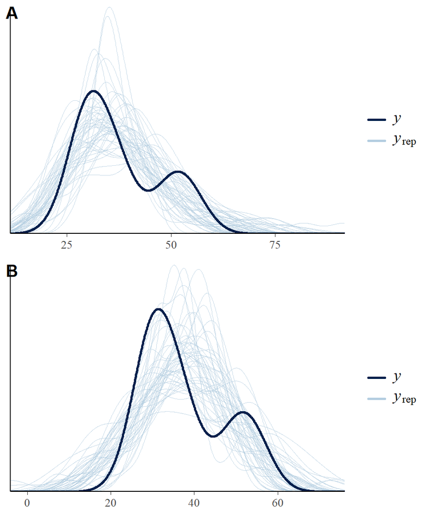

```r
pla<-pp_check(elisa_hp_model_01,type='dens_overlay',ndraws = 50)
plb<-pp_check(elisa_hp_model_02,type='dens_overlay',ndraws = 50)
plot_grid(pla, plb, labels=c("A", "B"), ncol = 1, nrow = 2)
```

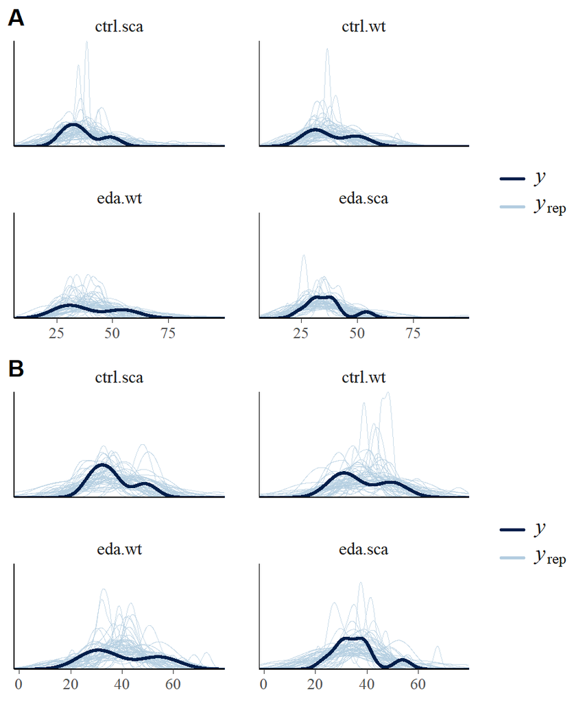

```r
pla<-pp_check(elisa_hp_model_01,type='dens_overlay_grouped',ndraws = 50,group='group')
plb<-pp_check(elisa_hp_model_02,type='dens_overlay_grouped',ndraws = 50,group='group')
plot_grid(pla, plb, labels=c("A", "B"), ncol = 1, nrow = 2)
```

```r
pla<-pp_check(elisa_hp_model_01,type='scatter_avg')
```

```
Using all posterior draws for ppc type 'scatter_avg' by default.
```

```r
plb<-pp_check(elisa_hp_model_02,type='scatter_avg')
```

```
Using all posterior draws for ppc type 'scatter_avg' by default.
```

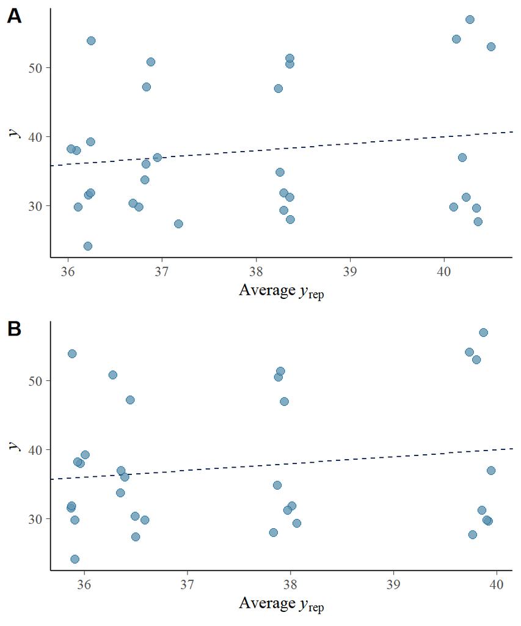

```r
plot_grid(pla, plb, labels=c("A", "B"), ncol = 1, nrow = 2)
```

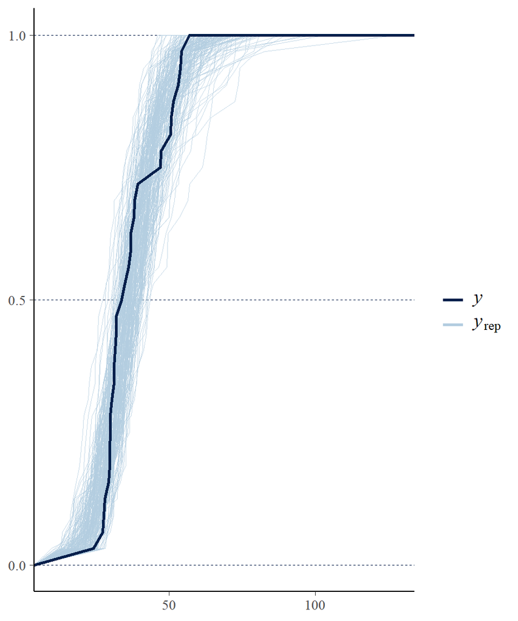

```r
pp_check(elisa_hp_model_01,type='ecdf_overlay',ndraws = 200)
```

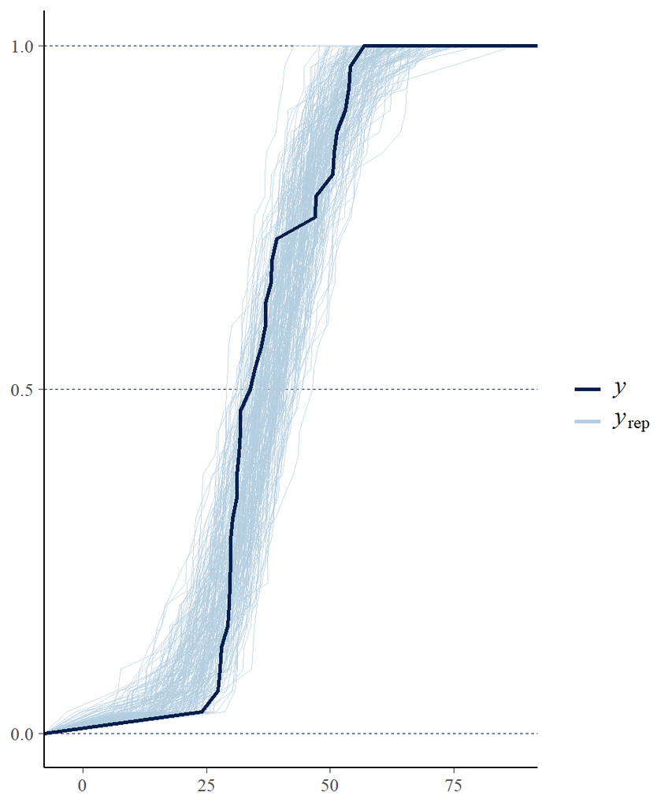

```r
pp_check(elisa_hp_model_02,type='ecdf_overlay',ndraws = 200)
```

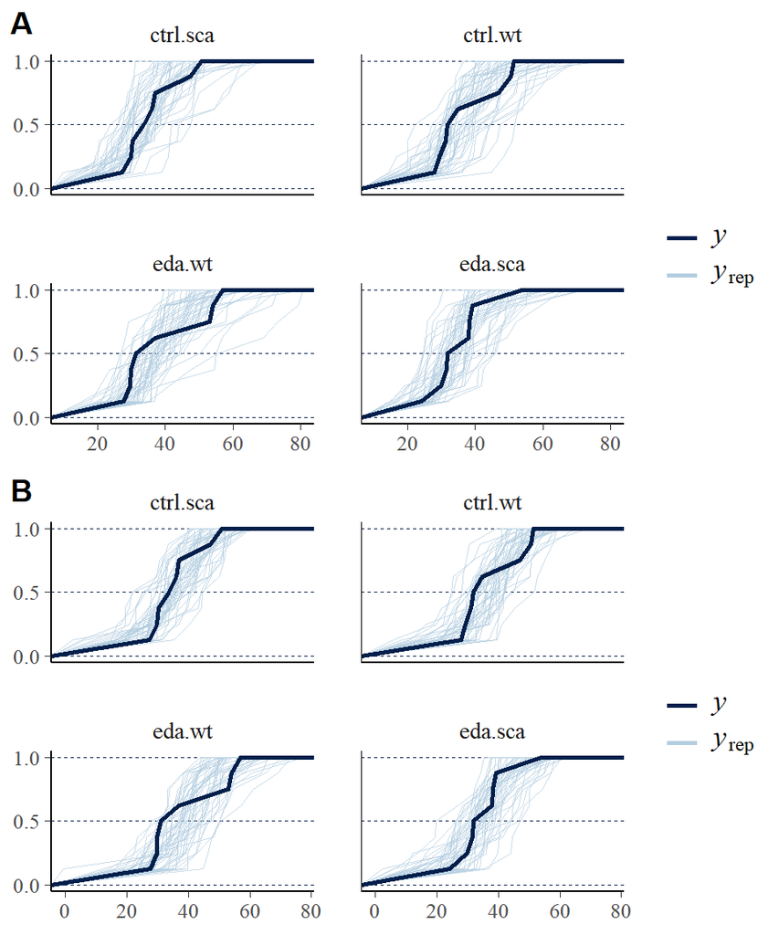

```r
pla<-pp_check(elisa_hp_model_01,type='ecdf_overlay_grouped',ndraws = 50,group='group')
plb<-pp_check(elisa_hp_model_02,type='ecdf_overlay_grouped',ndraws = 50,group='group')
plot_grid(pla, plb, labels=c("A", "B"), ncol = 1, nrow = 2)
```

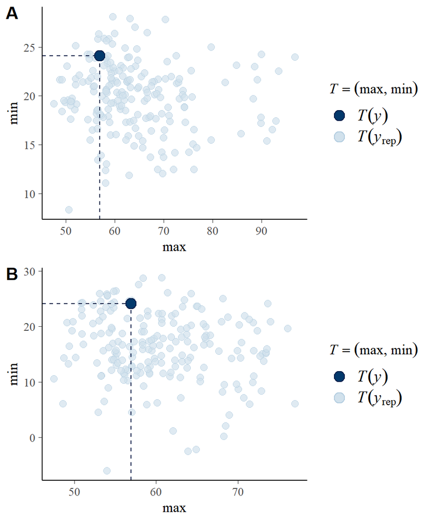

```r
pla<-pp_check(elisa_hp_model_01,type="stat_2d", stat = c("max", "min"),ndraws=200)
plb<-pp_check(elisa_hp_model_02,type="stat_2d", stat = c("max", "min"),ndraws=200)
plot_grid(pla, plb, labels=c("A", "B"), ncol = 1, nrow = 2)
```

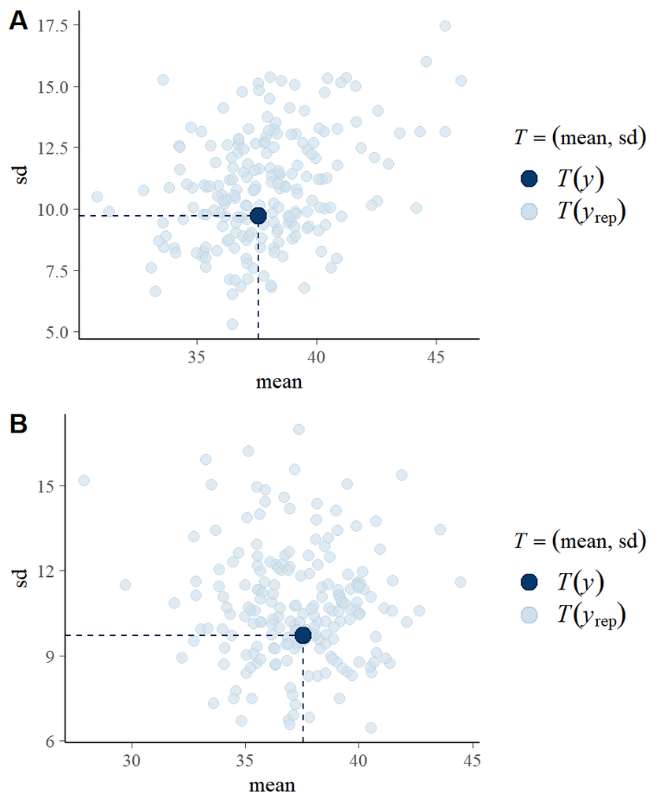

```r
pla<-pp_check(elisa_hp_model_01,type="stat_2d", stat = c("mean", "sd"),ndraws=200)
plb<-pp_check(elisa_hp_model_02,type="stat_2d", stat = c("mean", "sd"),ndraws=200)
plot_grid(pla, plb, labels=c("A", "B"), ncol = 1, nrow = 2)
```

```r
### Are there too influential observations?
par(mfrow=c(1,2))
plot(loo(elisa_hp_model_01));loo(elisa_hp_model_01)
```

```
Computed from 12000 by 32 log-likelihood matrix

         Estimate  SE
elpd_loo   -120.5 3.3
p_loo         4.3 0.7
looic       241.1 6.5
------
Monte Carlo SE of elpd_loo is 0.0.

All Pareto k estimates are good (k < 0.5).
See help('pareto-k-diagnostic') for details.
```

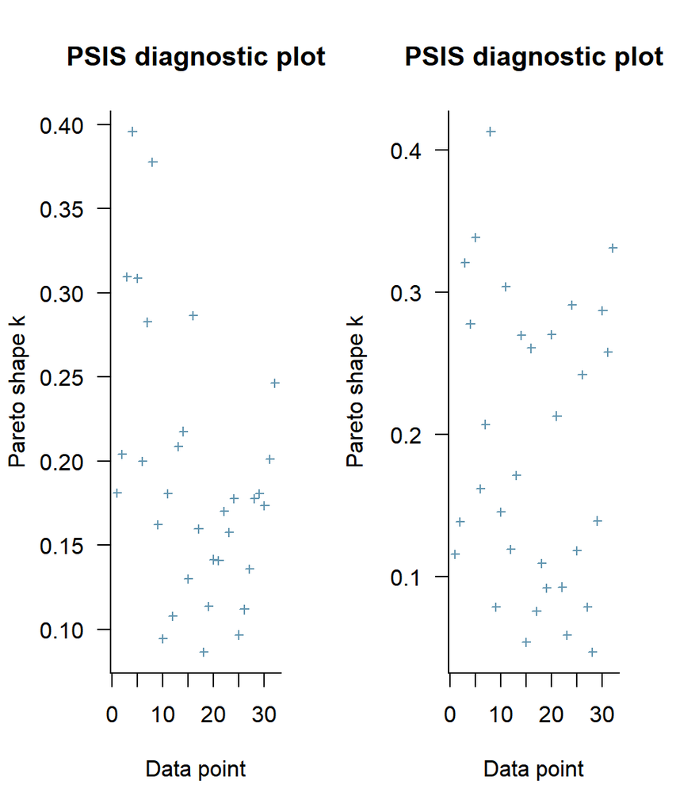

```
Computed from 12000 by 32 log-likelihood matrix

         Estimate  SE
elpd_loo   -122.0 2.9
p_loo         4.1 0.7
looic       244.0 5.7
------
Monte Carlo SE of elpd_loo is 0.0.

All Pareto k estimates are good (k < 0.5).
See help('pareto-k-diagnostic') for details.
```

```r
plot(loo(elisa_hp_model_02));loo(elisa_hp_model_02)
```

Both models seem to fit the data relatively well. For simplicity, we will use Gaussian models

### 3.2.4 Extraction of posterior samples

```r
post_fix<-as.data.frame(elisa_hp_model_02, variable = c("b_Intercept","b_groupctrl.wt",
                                                       "b_groupeda.wt","b_groupeda.sca"))
names(post_fix)[1]<-"sca_ctrl"

post_fix$wt_ctrl<-post_fix$sca_ctrl+post_fix$b_groupctrl.wt
post_fix$wt_eda<-post_fix$sca_ctrl+post_fix$b_groupeda.wt
post_fix$sca_eda<-post_fix$sca_ctrl+post_fix$b_groupeda.sca
post_fix$wt_contrast<-post_fix$wt_eda-post_fix$wt_ctrl
summary(post_fix)
```

```
    sca_ctrl     b_groupctrl.wt    b_groupeda.wt      b_groupeda.sca
 Min.   :23.88   Min.   :-19.364   Min.   :-18.8974   Min.   :-18.5055
 1st Qu.:34.24   1st Qu.: -1.665   1st Qu.:  0.2454   1st Qu.: -3.6530
 Median :36.45   Median :  1.461   Median :  3.3817   Median : -0.6670
 Mean   :36.48   Mean   :  1.497   Mean   :  3.3911   Mean   : -0.5931
 3rd Qu.:38.73   3rd Qu.:  4.718   3rd Qu.:  6.5097   3rd Qu.:  2.5098
 Max.   :48.88   Max.   : 20.800   Max.   : 25.5243   Max.   : 16.4948
    wt_ctrl          wt_eda         sca_eda       wt_contrast
 Min.   :22.59   Min.   :22.99   Min.   :23.53   Min.   :-17.600
 1st Qu.:35.66   1st Qu.:37.53   1st Qu.:33.56   1st Qu.: -1.412
 Median :37.94   Median :39.87   Median :35.84   Median :  1.891
 Mean   :37.97   Mean   :39.87   Mean   :35.88   Mean   :  1.894
 3rd Qu.:40.34   3rd Qu.:42.22   3rd Qu.:38.18   3rd Qu.:  5.264
 Max.   :52.70   Max.   :57.23   Max.   :50.85   Max.   : 22.082
```

```r
groupquant<-sapply(post_fix[,c(5,6,1,7)],function(p) quantile(p, probs = c(0.025,0.975,0.5)))
groupquant<-(groupquant)
```

## 3.3 Vizualisation

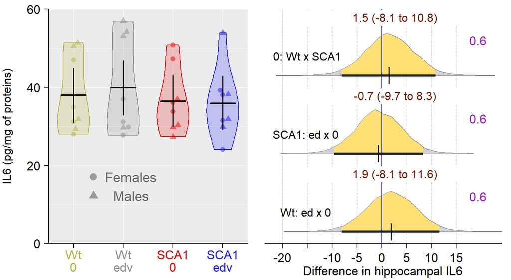

```r
## showing data

elisa_hp$group<-factor(elisa_hp$group,levels=c('ctrl.wt','eda.wt','ctrl.sca','eda.sca'))

par(mfrow=c(1,2))
par(mar=c(2,3,0,0))
par(mgp=c(2,0.6,0))
range<-c(0,60);scal<-range[2]-range[1]
xrange<-c(0.5,4.5);xscal=xrange[2]-xrange[1]
plot(NULL,xlim=c(xrange[1],xrange[2]),ylim=c(range[1],range[2]),xlab="",
     ylab="IL6 (pg/mg of proteins)",las=1, axes=FALSE,cex.lab=1)

rect(xrange[1],range[2],xrange[2],range[1],col="grey92",border=NA)
x<-range[1]
repeat{
  lines(c(xrange[1],xrange[2]),c(x,x),col="white",lwd=0.7)
  x=x+10;if(x>range[2]){break}}

x<-1
repeat{
  lines(c(x,x),c(range[1],range[2]),col="white",lwd=0.7)
  x=x+1;if(x>4.5){break}}

vioplot(elisa_hp$il6~elisa_hp$group,col=colb,at=c(1:4),add=T,
        border=cola,axes=FALSE,drawRect=F,lwd=1,wex=0.8)

beeswarm(elisa_hp$il6~elisa_hp$group,col=colc,at=c(1:4),
         add=T,pwpch=(16.5+elisa_hp$sex_num) )

tp<-(groupquant[3,])
xx<-1;wid=0.25
repeat{
  lines(c(xx-wid,xx+wid),c(tp[xx],tp[xx]),lwd=2,col="black");
  lines(c(xx,xx),c(groupquant[1,xx],groupquant[2,xx]),lwd=1.7,col="black")
  xx<-xx+1
  if(xx>4){break}}

tckk=-0.02
axis(2,las=2,cex.axis=1.1,at=seq(range[1],range[2],by=20),
     labels=c(rep("",length(seq(range[1],range[2],by=20)))),pos=xrange[1],tck=tckk)
axis(2,las=2,cex.axis=1.1,at=seq(range[1],range[2],by=20),pos=xrange[1],tck=tckk)

axis(side=1,las=1,cex.axis=1.1,at=c(seq(1,4,by=1)),
     labels=c(rep("",length(seq(1,4,by=1)))),pos=range[1],tck=tckk)
lines(c(xrange[1],xrange[2]),c(range[1],range[1]))
text(c(1:4),c(rep(range[1]-0.046*scal,4)),xpd=T,cex=1.1,col=cola,
     c("Wt","Wt", "SCA1", "SCA1"))
ypo<-c(range[1]-0.1*scal,range[1]-0.1*scal)
text(c(1:4),c(ypo[1],ypo[2],ypo[1],ypo[2]),xpd=T,cex=1.1,col=cola,
     c("0","edv", "0", "edv"))

ypos<-17;xpos=1.4
points(xpos,ypos,pch=16,cex=1.4,col=rgb(0.4,0.4,0.4,alpha=0.6))
text(xpos+0.19*xscal,ypos,"Females",col="grey40",cex=1.2)
points(xpos,ypos-0.08*scal,pch=17,cex=1.4,col=rgb(0.4,0.4,0.4,alpha=0.6))
text(xpos+0.19*xscal,ypos-0.08*scal,"Males",col="grey40",cex=1.2)

## posterior probability distributions for between-groups difference
par(mar=c(2,0,0,0))
dif<-data.frame(post_fix$wt_contrast,post_fix$b_groupeda.sca,
                post_fix$b_groupctrl.wt)
dif<-(dif)

yla<-"Difference in hippocampal IL6"
tckk=-0.018
ste<-seq(-20,15,by=5)
mons_poste(dif,0)

zpos=seq(0,1,1/3)
xx=1;ind=0.4;xpol<--15
text(xpol,zpos[xx]+zpos[2]*ind,
     "Wt: ed x 0 ",cex=1)
xx=xx+1

text(xpol,zpos[xx]+zpos[2]*ind,
     "SCA1: ed x 0 ",cex=1)
xx=xx+1

text(xpol,zpos[xx]+zpos[2]*ind,
     "0: Wt x SCA1",cex=1)
```

# 4 Cerebellar IL6

## 4.1 Data exploration

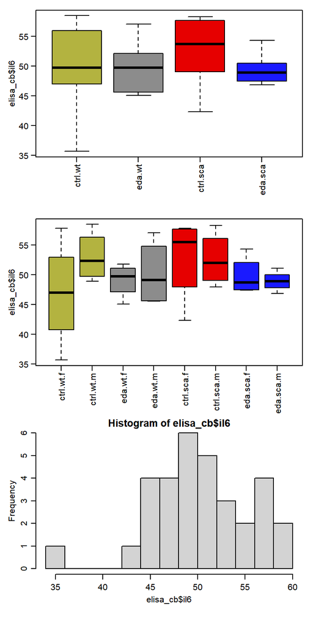

```r
par(mar=c(5,3.5,1,1))
par(mgp=c(1.9,0.7,0))
par(mfrow=c(3,1))


plot(elisa_cb$il6~elisa_cb$group,las=2,xlab="",
     col=cola)

plot(elisa_cb$il6~elisa_cb$group_sex,las=2,xlab="",
     col=cola[c(1,1,2,2,3,3,4,4)])

hist(elisa_cb$il6, 12)
```

No consistent sex effect. Distribution seems relatively symetrical. We will again fit both gamma and Gaussian models

## 4.2 Modelling

### 4.2.1 Setting priors

Summary statistics and other information used for prior specification

```r
elisa_cb$group<-relevel(elisa_cb$group,ref='ctrl.sca')

## prior for gamma models
log(mean(elisa_cb$il6))
```

```
[1] 3.919395
```

```r
sd(log(elisa_cb$il6))*5
```

```
[1] 0.5294394
```

```r
## prior for Gaussian model
mean(elisa_cb$il6)
```

```
[1] 50.36994
```

```r
sd(elisa_cb[elisa_cb$genotype=="sca",]$il6) * c(5, 2, 1.2)
```

```
[1] 22.569138  9.027655  5.416593
```

```r
sd(elisa_cb[elisa_cb$genotype=="wt",]$il6) * c(5, 2, 1.2)
```

```
[1] 28.908948 11.563579  6.938147
```

```r
sd(elisa_cb$il6)* c(5, 2, 1.2)
```

```
[1] 25.699076 10.279630  6.167778
```

Defining priors

```r
## Priors for gamma model
prior01 <- c(set_prior("student_t(3, 3.9, 0.53)", class = "b", coef = "Intercept"),
             set_prior("normal(0, 2)", class = "b", coef = "groupctrl.wt"),
             set_prior("normal(0, 2)", class = "b", coef = "groupeda.wt"),
             set_prior("normal(0, 1.2)"  , class = "b", coef = "groupeda.sca"))

## Priors for Gaussian model
prior02 <- c(set_prior("student_t(3, 50, 26)", class = "b", coef = "Intercept"),
             set_prior("normal(0, 11.6)", class = "b", coef = "groupctrl.wt"),
             set_prior("normal(0, 11.6)", class = "b", coef = "groupeda.wt"),
             set_prior("normal(0, 5.4)"  , class = "b", coef = "groupeda.sca"))
```

### 4.2.2 Fitting models and convergence check

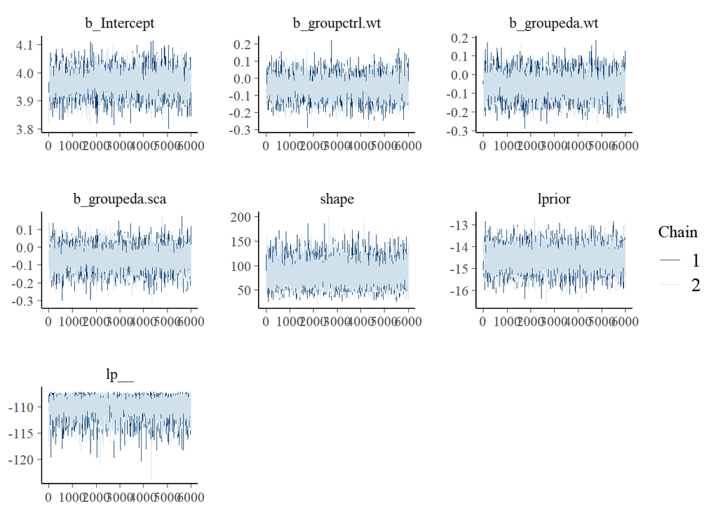

```r
## gamma model
elisa_cb_model_01 <- run_model(
                brm(il6 ~0+Intercept+group,
                      data=elisa_cb, prior = prior01,
                      family=Gamma(link="log"),
                      save_pars = save_pars(all = TRUE),
                      iter=8000, warmup=2000,chains=2,cores=1,seed=17,
                      control = list(adapt_delta = 0.99)),
                 'output/brm/elisa_cb_model_01', reuse = TRUE)

## Gaussian model
elisa_cb_model_02 <- run_model(
              brm(il6~0+Intercept+group,
                      data=elisa_cb, prior = prior02,
                      family=gaussian(),
                      save_pars = save_pars(all = TRUE),
                      iter=8000, warmup=2000,chains=2,cores=1,seed=17,
                      control = list(adapt_delta = 0.99)),
                 'output/brm/elisa_cb_model_02', reuse = TRUE)

mcmc_trace(elisa_cb_model_01)
```

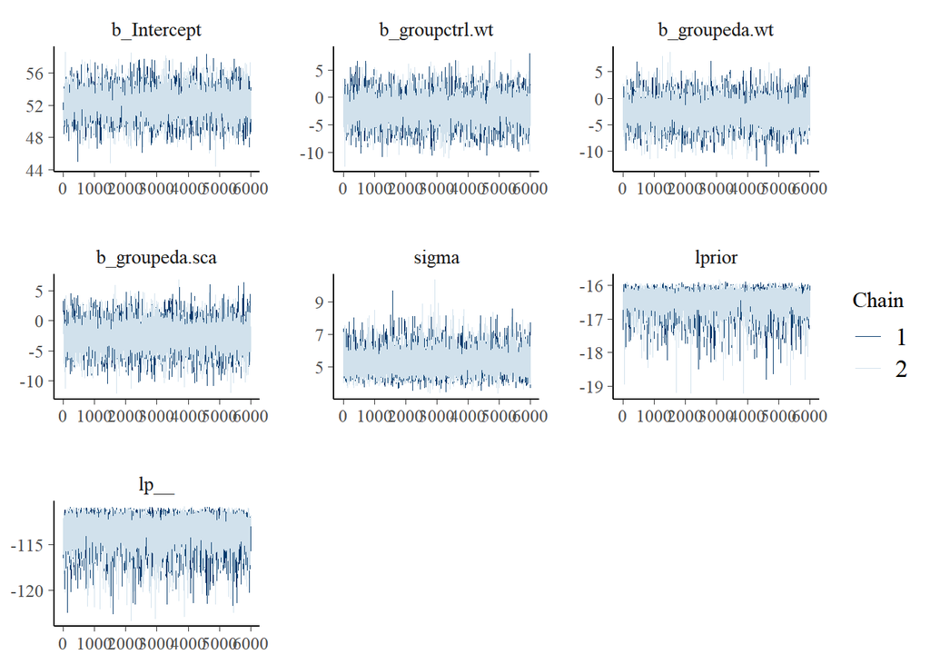

```r
mcmc_trace(elisa_cb_model_02)
```

```r
summary(elisa_cb_model_01)
```

```
 Family: gamma
  Links: mu = log; shape = identity
Formula: il6 ~ 0 + Intercept + group
   Data: elisa_cb (Number of observations: 32)
  Draws: 2 chains, each with iter = 8000; warmup = 2000; thin = 1;
         total post-warmup draws = 12000

Population-Level Effects:
             Estimate Est.Error l-95% CI u-95% CI Rhat Bulk_ESS Tail_ESS
Intercept        3.96      0.04     3.88     4.04 1.00     3200     4824
groupctrl.wt    -0.05      0.06    -0.16     0.06 1.00     3825     5585
groupeda.wt     -0.06      0.06    -0.17     0.06 1.00     4043     5766
groupeda.sca    -0.06      0.06    -0.18     0.05 1.00     3974     5394

Family Specific Parameters:
      Estimate Est.Error l-95% CI u-95% CI Rhat Bulk_ESS Tail_ESS
shape    83.47     22.45    44.92   131.80 1.00     5794     6455

Draws were sampled using sampling(NUTS). For each parameter, Bulk_ESS
and Tail_ESS are effective sample size measures, and Rhat is the potential
scale reduction factor on split chains (at convergence, Rhat = 1).
```

```r
summary(elisa_cb_model_02)
```

```
 Family: gaussian
  Links: mu = identity; sigma = identity
Formula: il6 ~ 0 + Intercept + group
   Data: elisa_cb (Number of observations: 32)
  Draws: 2 chains, each with iter = 8000; warmup = 2000; thin = 1;
         total post-warmup draws = 12000

Population-Level Effects:
             Estimate Est.Error l-95% CI u-95% CI Rhat Bulk_ESS Tail_ESS
Intercept       52.17      1.74    48.76    55.60 1.00     4169     6061
groupctrl.wt    -2.20      2.50    -7.11     2.74 1.00     5204     6390
groupeda.wt     -2.50      2.51    -7.48     2.43 1.00     4934     6637
groupeda.sca    -2.55      2.36    -7.18     2.12 1.00     4943     6309

Family Specific Parameters:
      Estimate Est.Error l-95% CI u-95% CI Rhat Bulk_ESS Tail_ESS
sigma     5.32      0.72     4.14     6.95 1.00     7125     7285

Draws were sampled using sampling(NUTS). For each parameter, Bulk_ESS
and Tail_ESS are effective sample size measures, and Rhat is the potential
scale reduction factor on split chains (at convergence, Rhat = 1).
```

Convergence of both models is fine, ESSs are sufficient

### 4.2.3 PPC

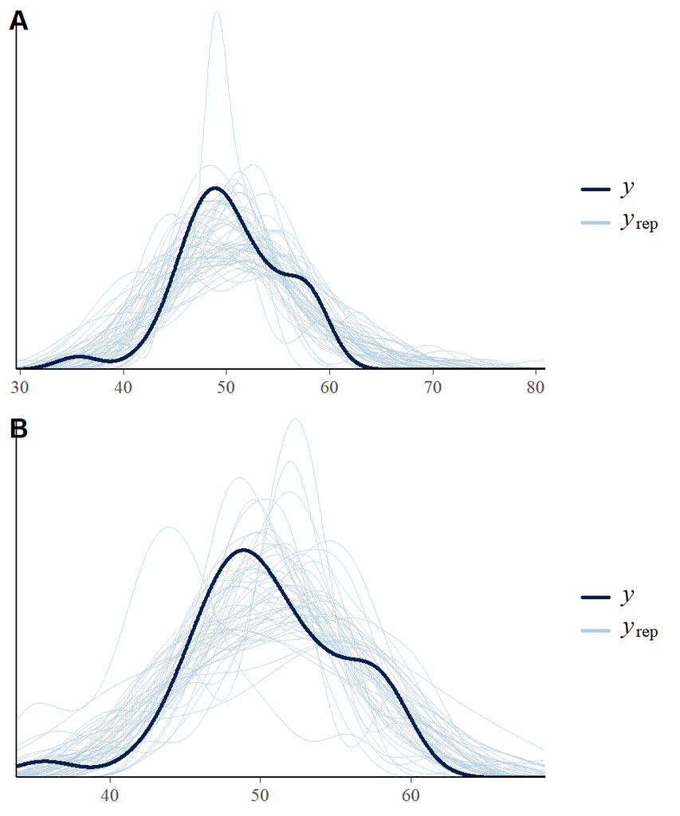

```r
pla<-pp_check(elisa_cb_model_01,type='dens_overlay',ndraws = 50)
plb<-pp_check(elisa_cb_model_02,type='dens_overlay',ndraws = 50)
plot_grid(pla, plb, labels=c("A", "B"), ncol = 1, nrow = 2)
```

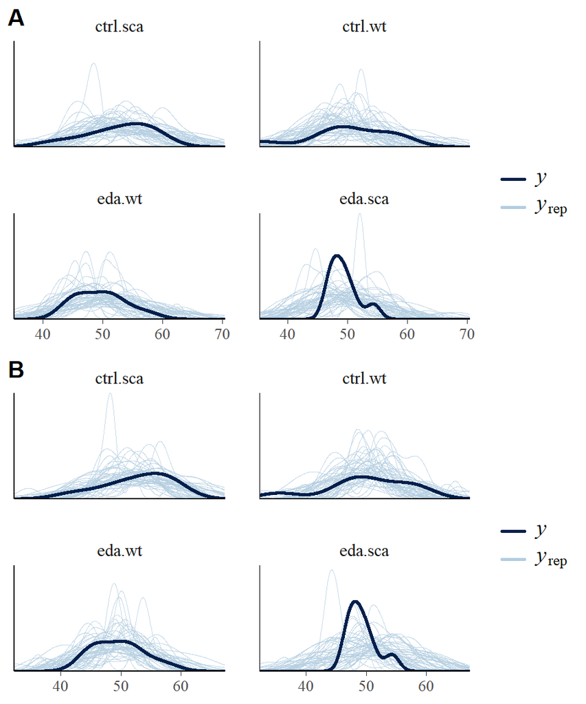

```r
pla<-pp_check(elisa_cb_model_01,type='dens_overlay_grouped',ndraws = 50,group='group')
plb<-pp_check(elisa_cb_model_02,type='dens_overlay_grouped',ndraws = 50,group='group')
plot_grid(pla, plb, labels=c("A", "B"), ncol = 1, nrow = 2)
```

```r
pla<-pp_check(elisa_cb_model_01,type='scatter_avg')
```

```
Using all posterior draws for ppc type 'scatter_avg' by default.
```

```r
plb<-pp_check(elisa_cb_model_02,type='scatter_avg')
```

```
Using all posterior draws for ppc type 'scatter_avg' by default.
```

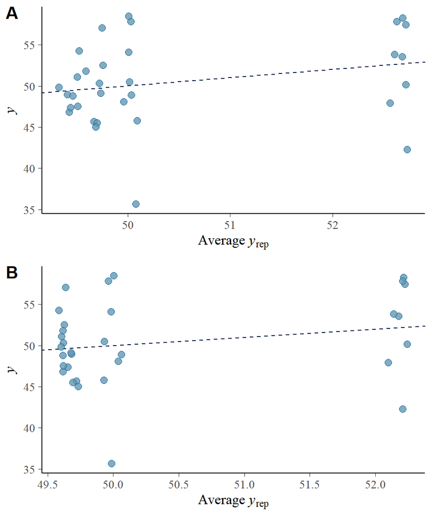

```r
plot_grid(pla, plb, labels=c("A", "B"), ncol = 1, nrow = 2)
```

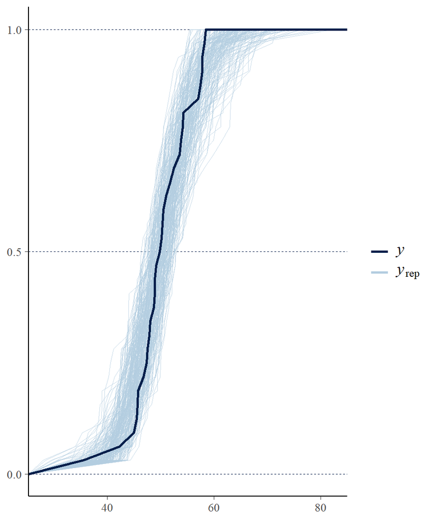

```r
pp_check(elisa_cb_model_01,type='ecdf_overlay',ndraws = 200)
```

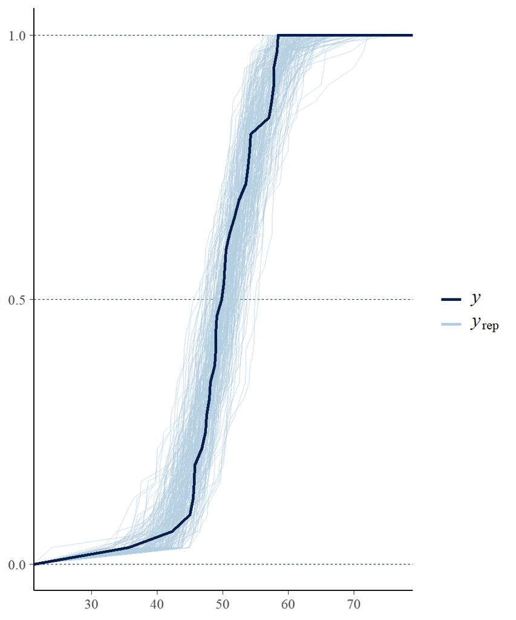

```r
pp_check(elisa_cb_model_02,type='ecdf_overlay',ndraws = 200)
```

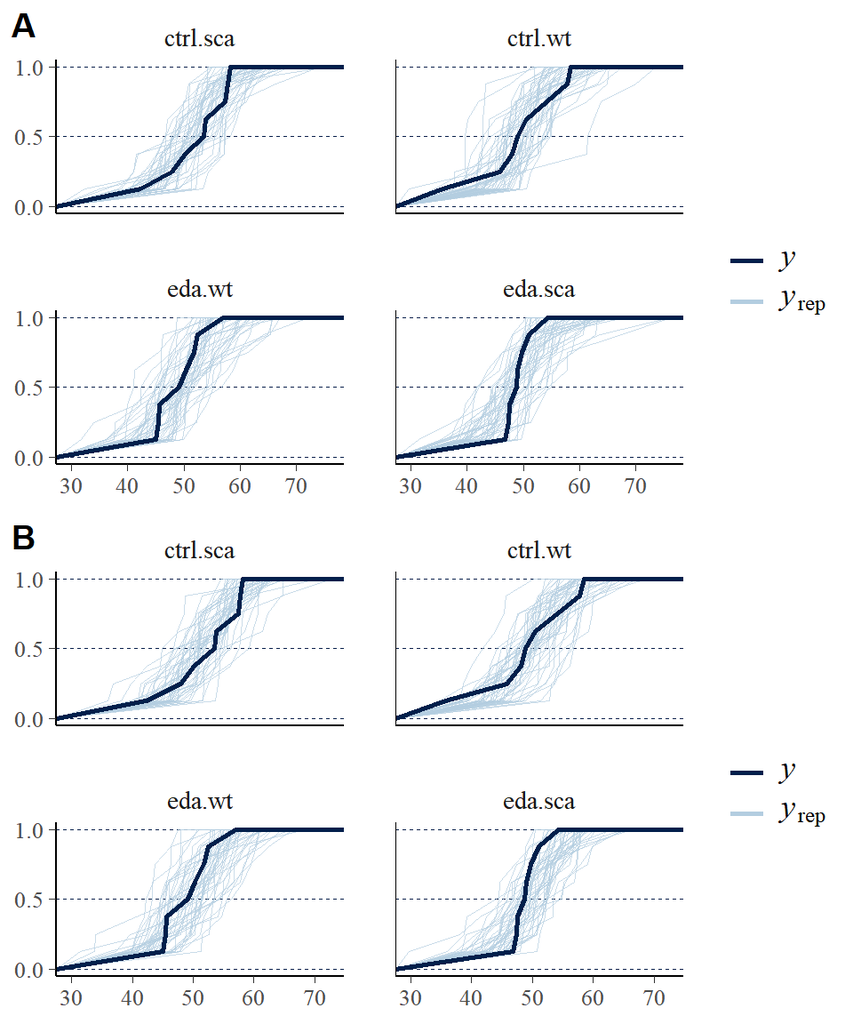

```r
pla<-pp_check(elisa_cb_model_01,type='ecdf_overlay_grouped',ndraws = 50,group='group')
plb<-pp_check(elisa_cb_model_02,type='ecdf_overlay_grouped',ndraws = 50,group='group')
plot_grid(pla, plb, labels=c("A", "B"), ncol = 1, nrow = 2)
```

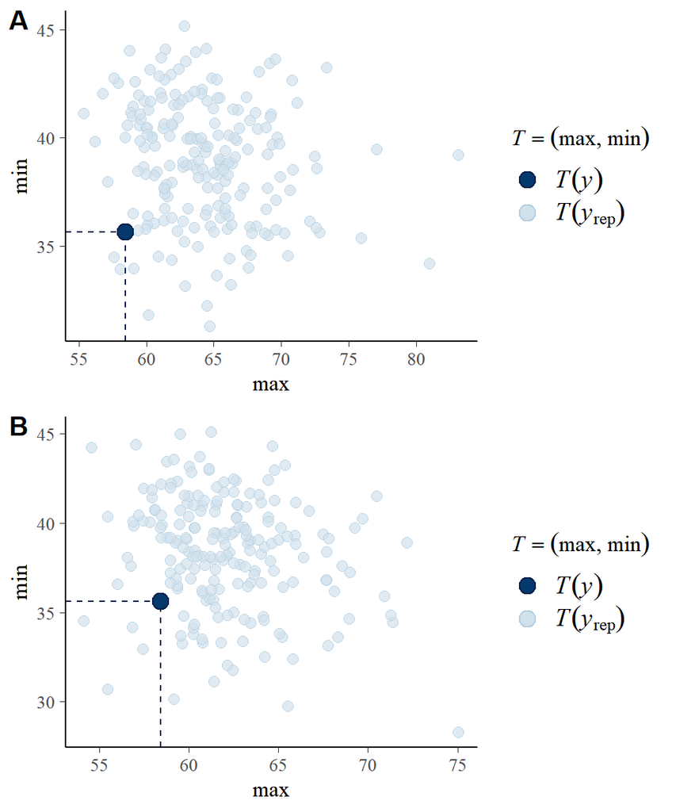

```r
pla<-pp_check(elisa_cb_model_01,type="stat_2d", stat = c("max", "min"),ndraws=200)
plb<-pp_check(elisa_cb_model_02,type="stat_2d", stat = c("max", "min"),ndraws=200)
plot_grid(pla, plb, labels=c("A", "B"), ncol = 1, nrow = 2)
```

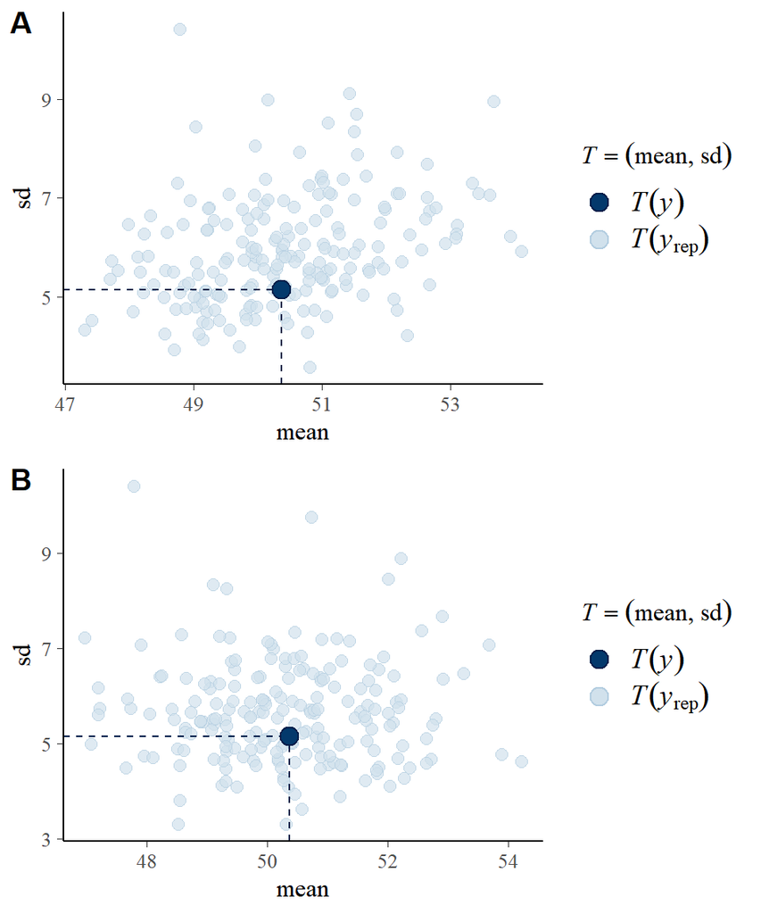

```r
pla<-pp_check(elisa_cb_model_01,type="stat_2d", stat = c("mean", "sd"),ndraws=200)
plb<-pp_check(elisa_cb_model_02,type="stat_2d", stat = c("mean", "sd"),ndraws=200)
plot_grid(pla, plb, labels=c("A", "B"), ncol = 1, nrow = 2)
```

```r
### Are there too influential observations?
par(mfrow=c(1,2))
plot(loo(elisa_cb_model_01));loo(elisa_cb_model_01)
```

```
Computed from 12000 by 32 log-likelihood matrix

         Estimate   SE
elpd_loo   -102.8  5.5
p_loo         5.1  2.0
looic       205.5 11.1
------
Monte Carlo SE of elpd_loo is NA.

Pareto k diagnostic values:
                         Count Pct.    Min. n_eff
(-Inf, 0.5]   (good)     31    96.9%   1417
 (0.5, 0.7]   (ok)        0     0.0%   <NA>
   (0.7, 1]   (bad)       1     3.1%   216
   (1, Inf)   (very bad)  0     0.0%   <NA>
See help('pareto-k-diagnostic') for details.
```

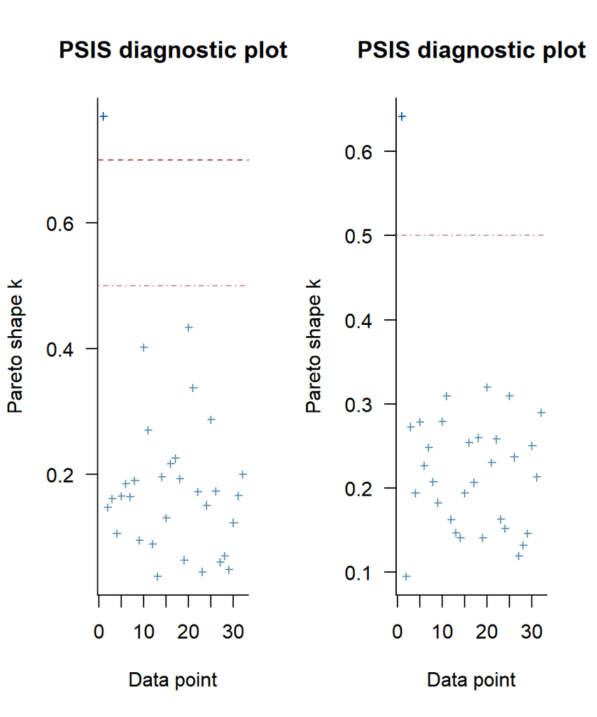

```
Computed from 12000 by 32 log-likelihood matrix

         Estimate   SE
elpd_loo   -101.6  5.4
p_loo         4.9  1.8
looic       203.1 10.8
------
Monte Carlo SE of elpd_loo is 0.1.

Pareto k diagnostic values:
                         Count Pct.    Min. n_eff
(-Inf, 0.5]   (good)     31    96.9%   1650
 (0.5, 0.7]   (ok)        1     3.1%   330
   (0.7, 1]   (bad)       0     0.0%   <NA>
   (1, Inf)   (very bad)  0     0.0%   <NA>

All Pareto k estimates are ok (k < 0.7).
See help('pareto-k-diagnostic') for details.
```

```r
plot(loo(elisa_cb_model_02));loo(elisa_cb_model_02)
```

Both models seem to fit the data relatively well. One observation is apparently outlier, with overly large impact on estimation. The large influence is seen particularly slightly more strongly in gamma model. Again, we will prefer Gaussian model, although both draw the same conlcusions.

### 4.2.4 Extraction of posterior samples

```r
post_fix <- as.data.frame(elisa_cb_model_02, variable = c("b_Intercept","b_groupctrl.wt",
                                                       "b_groupeda.wt","b_groupeda.sca"))
names(post_fix)[1] <- "sca_ctrl"

post_fix$wt_ctrl <- post_fix$sca_ctrl+post_fix$b_groupctrl.wt
post_fix$wt_eda <- post_fix$sca_ctrl+post_fix$b_groupeda.wt
post_fix$sca_eda <- post_fix$sca_ctrl+post_fix$b_groupeda.sca
post_fix$wt_contrast <- post_fix$wt_eda-post_fix$wt_ctrl
summary(post_fix)
```

```
    sca_ctrl     b_groupctrl.wt     b_groupeda.wt      b_groupeda.sca
 Min.   :44.42   Min.   :-12.4358   Min.   :-12.8186   Min.   :-12.1552
 1st Qu.:51.02   1st Qu.: -3.8251   1st Qu.: -4.1481   1st Qu.: -4.1027
 Median :52.17   Median : -2.1950   Median : -2.4996   Median : -2.5641
 Mean   :52.17   Mean   : -2.1976   Mean   : -2.4955   Mean   : -2.5513
 3rd Qu.:53.31   3rd Qu.: -0.5862   3rd Qu.: -0.8297   3rd Qu.: -0.9773
 Max.   :58.56   Max.   :  8.1742   Max.   :  8.6824   Max.   :  6.8822
    wt_ctrl          wt_eda         sca_eda       wt_contrast
 Min.   :42.80   Min.   :42.24   Min.   :41.30   Min.   :-10.4207
 1st Qu.:48.75   1st Qu.:48.42   1st Qu.:48.45   1st Qu.: -2.0354
 Median :49.97   Median :49.69   Median :49.62   Median : -0.3192
 Mean   :49.97   Mean   :49.67   Mean   :49.62   Mean   : -0.2980
 3rd Qu.:51.18   3rd Qu.:50.92   3rd Qu.:50.79   3rd Qu.:  1.4553
 Max.   :58.05   Max.   :57.08   Max.   :56.67   Max.   : 10.1149
```

```r
groupquant<-sapply(post_fix[,c(5,6,1,7)],function(p) quantile(p, probs = c(0.025,0.975,0.5)))
groupquant<-(groupquant)
```

## 4.3 Vizualisation

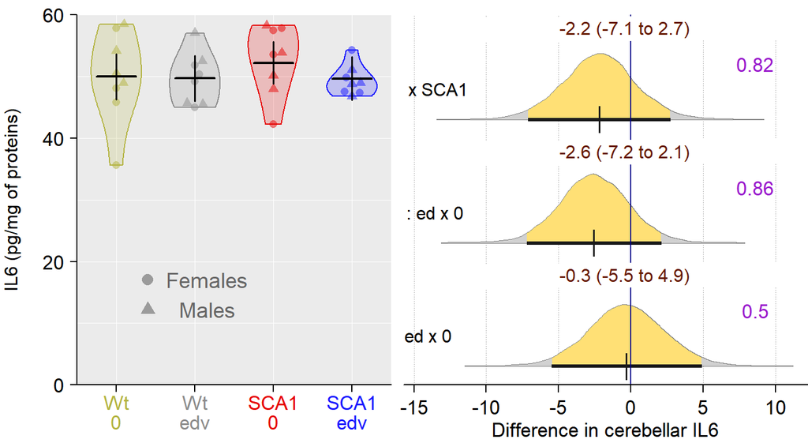

```r
## showing data

elisa_cb$group<-factor(elisa_cb$group,levels=c('ctrl.wt','eda.wt','ctrl.sca','eda.sca'))

par(mfrow=c(1,2))
par(mar=c(2,3,0,0))
par(mgp=c(2,0.6,0))
range<-c(0,60);scal<-range[2]-range[1]
xrange<-c(0.5,4.5);xscal=xrange[2]-xrange[1]
plot(NULL,xlim=c(xrange[1],xrange[2]),ylim=c(range[1],range[2]),xlab="",
     ylab="IL6 (pg/mg of proteins)",las=1, axes=FALSE,cex.lab=1)

rect(xrange[1],range[2],xrange[2],range[1],col="grey92",border=NA)
x<-range[1]
repeat{
  lines(c(xrange[1],xrange[2]),c(x,x),col="white",lwd=0.7)
  x=x+10;if(x>range[2]){break}}

x<-1
repeat{
  lines(c(x,x),c(range[1],range[2]),col="white",lwd=0.7)
  x=x+1;if(x>4.5){break}}

vioplot(elisa_cb$il6~elisa_cb$group,col=colb,at=c(1:4),add=T,
        border=cola,axes=FALSE,drawRect=F,lwd=1,wex=0.8)

beeswarm(elisa_cb$il6~elisa_cb$group,col=colc,at=c(1:4),
         add=T,pwpch=(16.5+elisa_cb$sex_num) )

tp<-(groupquant[3,])
xx<-1;wid=0.25
repeat{
  lines(c(xx-wid,xx+wid),c(tp[xx],tp[xx]),lwd=2,col="black");
  lines(c(xx,xx),c(groupquant[1,xx],groupquant[2,xx]),lwd=1.7,col="black")
  xx<-xx+1
  if(xx>4){break}}

tckk=-0.02
axis(2,las=2,cex.axis=1.1,at=seq(range[1],range[2],by=20),
     labels=c(rep("",length(seq(range[1],range[2],by=20)))),pos=xrange[1],tck=tckk)
axis(2,las=2,cex.axis=1.1,at=seq(range[1],range[2],by=20),pos=xrange[1],tck=tckk)

axis(side=1,las=1,cex.axis=1.1,at=c(seq(1,4,by=1)),
     labels=c(rep("",length(seq(1,4,by=1)))),pos=range[1],tck=tckk)
lines(c(xrange[1],xrange[2]),c(range[1],range[1]))
text(c(1:4),c(rep(range[1]-0.046*scal,4)),xpd=T,cex=1.1,col=cola,
     c("Wt","Wt", "SCA1", "SCA1"))
ypo<-c(range[1]-0.1*scal,range[1]-0.1*scal)
text(c(1:4),c(ypo[1],ypo[2],ypo[1],ypo[2]),xpd=T,cex=1.1,col=cola,
     c("0","edv", "0", "edv"))

ypos<-17;xpos=1.4
points(xpos,ypos,pch=16,cex=1.4,col=rgb(0.4,0.4,0.4,alpha=0.6))
text(xpos+0.19*xscal,ypos,"Females",col="grey40",cex=1.2)
points(xpos,ypos-0.08*scal,pch=17,cex=1.4,col=rgb(0.4,0.4,0.4,alpha=0.6))
text(xpos+0.19*xscal,ypos-0.08*scal,"Males",col="grey40",cex=1.2)

## posterior probability distributions for between-groups difference
par(mar=c(2,0,0,0))
dif<-data.frame(post_fix$wt_contrast,post_fix$b_groupeda.sca,
                post_fix$b_groupctrl.wt)
dif<-(dif)

yla<-"Difference in cerebellar IL6"
tckk=-0.018
ste<-seq(-20,15,by=5)
mons_poste(dif,0)

zpos=seq(0,1,1/3)
xx=1;ind=0.4;xpol<--15
text(xpol,zpos[xx]+zpos[2]*ind,
     "Wt: ed x 0 ",cex=1)
xx=xx+1

text(xpol,zpos[xx]+zpos[2]*ind,
     "SCA1: ed x 0 ",cex=1)
xx=xx+1

text(xpol,zpos[xx]+zpos[2]*ind,
     "0: Wt x SCA1",cex=1)
```

# 5 Cerebellar BDNF

## 5.1 Data exploration

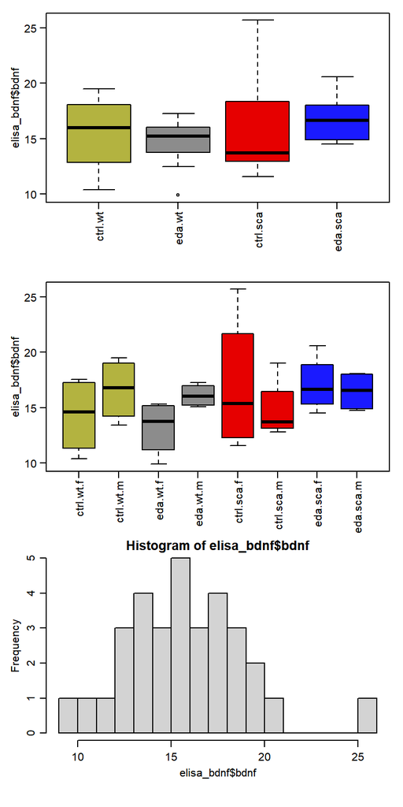

```r
par(mar=c(5,3.5,1,1))
par(mgp=c(1.9,0.7,0))
par(mfrow=c(3,1))


plot(elisa_bdnf$bdnf~elisa_bdnf$group,las=2,xlab="",
     col=cola)

plot(elisa_bdnf$bdnf~elisa_bdnf$group_sex,las=2,xlab="",
     col=cola[c(1,1,2,2,3,3,4,4)])

hist(elisa_bdnf$bdnf, 12)
```

There is no consistent sex-related difference, although specifically in WT, males show trend of higher BDNF levels. Distribution is symmetrical and spread is not larger in groups with larger values. However, we will be consistent with previous ELISA analyses and will also fit both gamma and Gaussian regression

## 5.2 Modelling

### 5.2.1 Setting priors

Summary statistics and other information used for prior specification

```r
elisa_bdnf$group<-relevel(elisa_bdnf$group,ref='ctrl.sca')

## prior for gamma models
log(mean(elisa_bdnf$bdnf))
```

```
[1] 2.753806
```

```r
sd(log(elisa_bdnf$bdnf))*5
```

```
[1] 1.003424
```

```r
## prior for Gaussian model
mean(elisa_bdnf$bdnf)
```

```
[1] 15.70229
```

```r
sd(elisa_bdnf[elisa_bdnf$genotype=="sca",]$bdnf) * c(5, 2, 1.2)
```

```
[1] 17.708605  7.083442  4.250065
```

```r
sd(elisa_bdnf[elisa_bdnf$genotype=="wt",]$bdnf) * c(5, 2, 1.2)
```

```
[1] 13.823583  5.529433  3.317660
```

```r
sd(elisa_bdnf$bdnf)* c(5, 2, 1.2)
```

```
[1] 15.963888  6.385555  3.831333
```

Defining priors

```r
## Priors for gamma model
prior01 <- c(set_prior("student_t(3, 2.8, 1)", class = "b", coef = "Intercept"),
             set_prior("normal(0, 2)", class = "b", coef = "groupctrl.wt"),
             set_prior("normal(0, 2)", class = "b", coef = "groupeda.wt"),
             set_prior("normal(0, 1.2)"  , class = "b", coef = "groupeda.sca"))

## Priors for Gaussian model
prior02 <- c(set_prior("student_t(3, 16, 16)", class = "b", coef = "Intercept"),
             set_prior("normal(0, 5.5)", class = "b", coef = "groupctrl.wt"),
             set_prior("normal(0, 5.5)", class = "b", coef = "groupeda.wt"),
             set_prior("normal(0, 4.3)"  , class = "b", coef = "groupeda.sca"))
```

### 5.2.2 Fitting models and convergence check

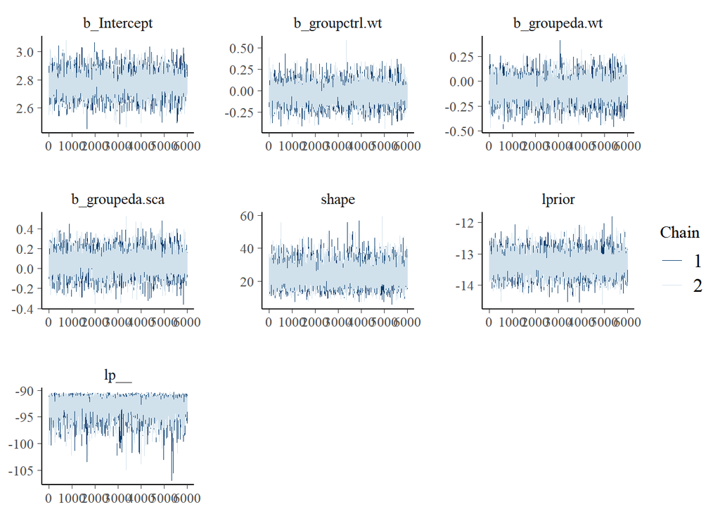

```r
## gamma model
elisa_bdnf_model_01 <- run_model(
                brm(bdnf ~0+Intercept+group,
                      data=elisa_bdnf, prior = prior01,
                      family=Gamma(link="log"),
                      save_pars = save_pars(all = TRUE),
                      iter=8000, warmup=2000,chains=2,cores=1,seed=17,
                      control = list(adapt_delta = 0.99)),
                 'output/brm/elisa_bdnf_model_01', reuse = TRUE)

## Gaussian model
elisa_bdnf_model_02 <- run_model(
              brm(bdnf~0+Intercept+group,
                      data=elisa_bdnf, prior = prior02,
                      family=gaussian(),
                      save_pars = save_pars(all = TRUE),
                      iter=8000, warmup=2000,chains=2,cores=1,seed=17,
                      control = list(adapt_delta = 0.99)),
                 'output/brm/elisa_bdnf_model_02', reuse = TRUE)

mcmc_trace(elisa_bdnf_model_01)
```

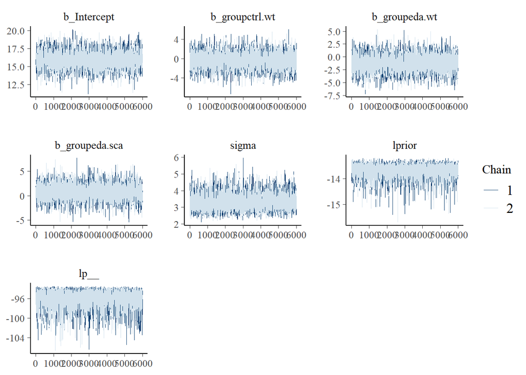

```r
mcmc_trace(elisa_bdnf_model_02)
```

```r
summary(elisa_bdnf_model_01)
```

```
 Family: gamma
  Links: mu = log; shape = identity
Formula: bdnf ~ 0 + Intercept + group
   Data: elisa_bdnf (Number of observations: 32)
  Draws: 2 chains, each with iter = 8000; warmup = 2000; thin = 1;
         total post-warmup draws = 12000

Population-Level Effects:
             Estimate Est.Error l-95% CI u-95% CI Rhat Bulk_ESS Tail_ESS
Intercept        2.77      0.08     2.62     2.92 1.00     3768     5459
groupctrl.wt    -0.03      0.11    -0.24     0.18 1.00     4584     5944
groupeda.wt     -0.08      0.11    -0.29     0.13 1.00     4329     5334
groupeda.sca     0.05      0.11    -0.16     0.26 1.00     4631     6046

Family Specific Parameters:
      Estimate Est.Error l-95% CI u-95% CI Rhat Bulk_ESS Tail_ESS
shape    23.55      6.21    13.08    37.23 1.00     5260     5868

Draws were sampled using sampling(NUTS). For each parameter, Bulk_ESS
and Tail_ESS are effective sample size measures, and Rhat is the potential
scale reduction factor on split chains (at convergence, Rhat = 1).
```

```r
summary(elisa_bdnf_model_02)
```

```
 Family: gaussian
  Links: mu = identity; sigma = identity
Formula: bdnf ~ 0 + Intercept + group
   Data: elisa_bdnf (Number of observations: 32)
  Draws: 2 chains, each with iter = 8000; warmup = 2000; thin = 1;
         total post-warmup draws = 12000

Population-Level Effects:
             Estimate Est.Error l-95% CI u-95% CI Rhat Bulk_ESS Tail_ESS
Intercept       15.90      1.10    13.74    18.10 1.00     3528     5061
groupctrl.wt    -0.40      1.57    -3.56     2.68 1.00     4177     5464
groupeda.wt     -1.20      1.55    -4.30     1.81 1.00     4350     5923
groupeda.sca     0.81      1.54    -2.24     3.86 1.00     4462     5476

Family Specific Parameters:
      Estimate Est.Error l-95% CI u-95% CI Rhat Bulk_ESS Tail_ESS
sigma     3.32      0.45     2.57     4.36 1.00     6257     7185

Draws were sampled using sampling(NUTS). For each parameter, Bulk_ESS
and Tail_ESS are effective sample size measures, and Rhat is the potential
scale reduction factor on split chains (at convergence, Rhat = 1).
```

Convergence of both models is fine, ESSs are sufficient

### 5.2.3 PPC

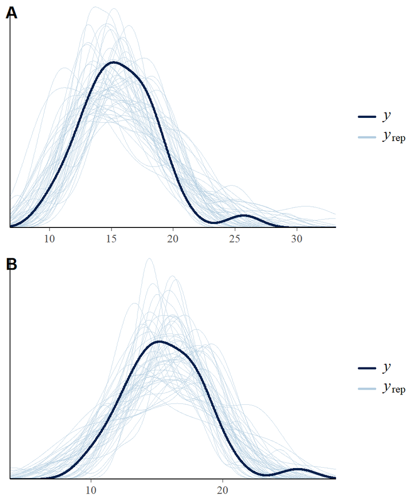

```r
pla<-pp_check(elisa_bdnf_model_01,type='dens_overlay',ndraws = 50)
plb<-pp_check(elisa_bdnf_model_02,type='dens_overlay',ndraws = 50)
plot_grid(pla, plb, labels=c("A", "B"), ncol = 1, nrow = 2)
```

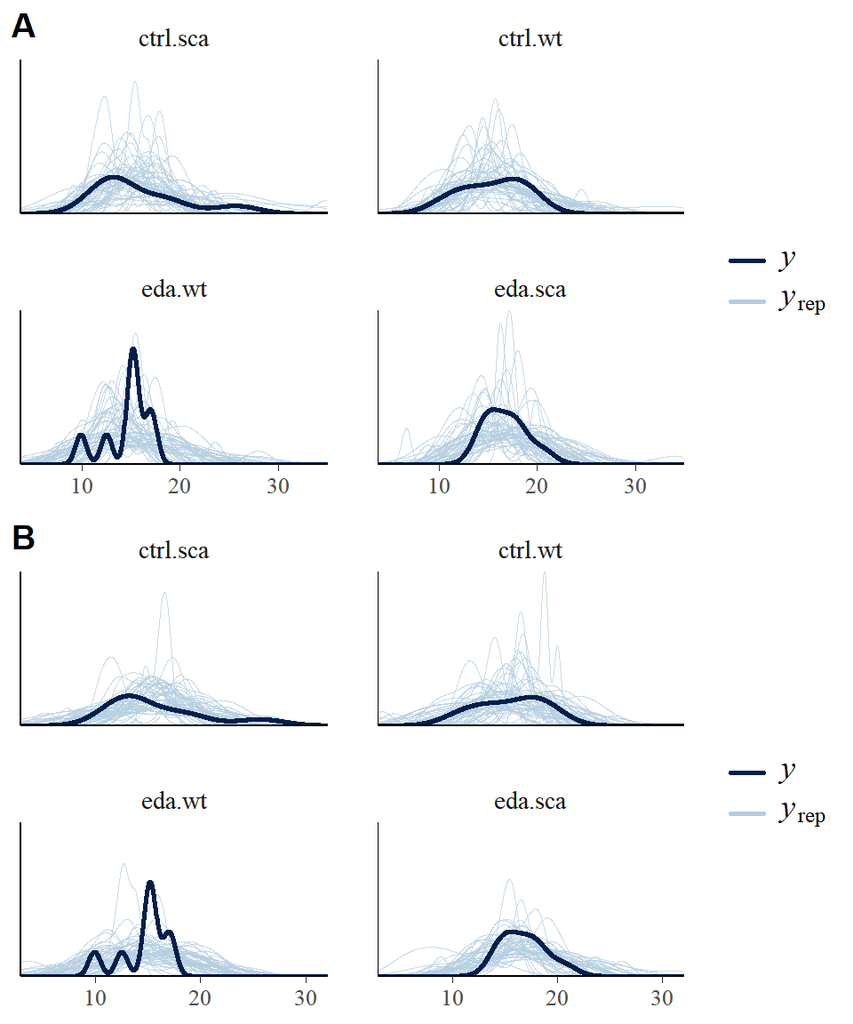

```r
pla<-pp_check(elisa_bdnf_model_01,type='dens_overlay_grouped',ndraws = 50,group='group')
plb<-pp_check(elisa_bdnf_model_02,type='dens_overlay_grouped',ndraws = 50,group='group')
plot_grid(pla, plb, labels=c("A", "B"), ncol = 1, nrow = 2)
```

```r
pla<-pp_check(elisa_bdnf_model_01,type='scatter_avg')
```

```
Using all posterior draws for ppc type 'scatter_avg' by default.
```

```r
plb<-pp_check(elisa_bdnf_model_02,type='scatter_avg')
```

```
Using all posterior draws for ppc type 'scatter_avg' by default.
```

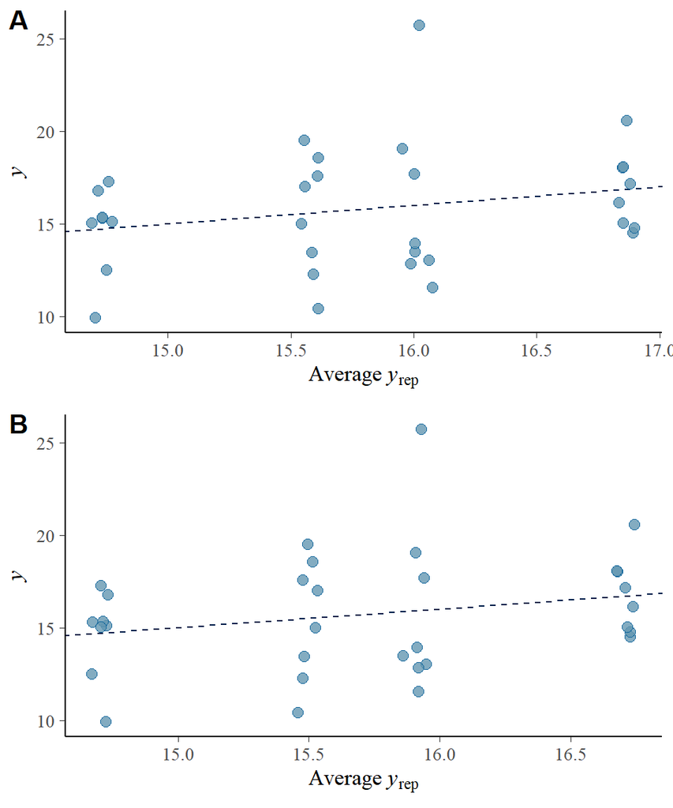

```r
plot_grid(pla, plb, labels=c("A", "B"), ncol = 1, nrow = 2)
```